# Atlantic Halibut Survival Analysis

Ethyn Deamos

2023-11-28

## Overview

The purpose of this analysis was to investigate the survival times of a collection of Atlantic halibut. In particular, we were interested in determining which variables significantly affected the survival rate. The data was provided for us on Canvas, and consisted of 294 observations on eight variables.

We first determined that the probability of survival was significantly higher for halibut with a 30-minute tow duration than a 100-minute tow duration. Then, using a shared frailty model, we found that when considering other variables, the most important predictors of survival were a fish’s fork length and the handling time between the net coming on board and the fish being placed in a holding tank.

```r
# Load necessary packages.
library(tidyverse)
library(survival)
library(ggfortify)
library(ggpubr)
library(frailtyEM)
library(MASS)
```

## Data

|  | time | censor | towd | deldepth | length | handtime | logcat |
| --- | --- | --- | --- | --- | --- | --- | --- |
| 1 | 209 | 1 | 30 | 13 | 41 | 8 | 6.992 |
| 2 | 209 | 1 | 30 | 13 | 44 | 8 | 6.992 |
| 3 | 209 | 1 | 30 | 13 | 47 | 10 | 6.992 |
| 4 | 209 | 1 | 30 | 13 | 34 | 10 | 6.992 |
| 5 | 38 | 1 | 30 | 13 | 40 | 11 | 6.992 |
| 6 | 209 | 1 | 30 | 13 | 42 | 11 | 6.992 |

The data consists of 294 observations on 8 variables. TIME is the survival time of halibut in hours. CENSOR is a censoring indicator (1 for uncensored, 0 for censored). TOWD is the duration in minutes of time trawl net was towed on the bottom. DELDEPTH is the difference between maximum and minimum depth observed during tow (measured in meters). LENGTH is the fork length of halibut in centimeters. HANDTIME is the handling time in minutes between net coming on board vessel and fish being placed in holding tanks. LOGCAT is the natural logarithm of the total catch of fish in tow. NO is the observation number.

### Exploratory Analysis

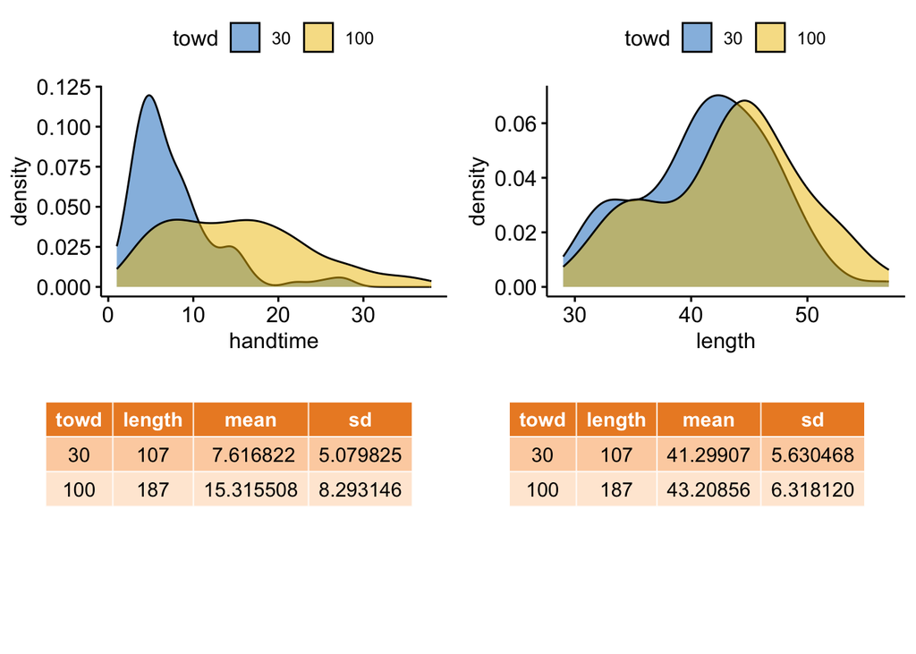

Figure 1: Density Plots and Summary Statistics for Handling Time and Length by Tow Duration.

### QUESTION 1

We want to investigate whether or not there is a significant difference in the survival rates for the two tow durations.

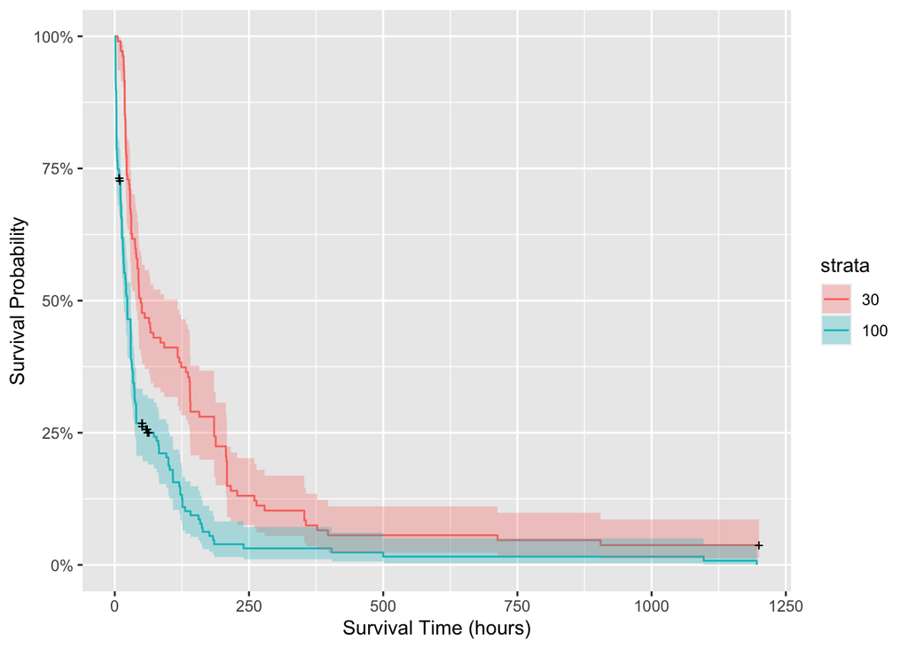

Figure 2: Kaplan-Meier Estimates of Survival Curves for Different Tow Durations.

We can clearly see a difference in the survival curves for different tow durations. In order to formally test the hypothesis of no group difference ($H_0: h_1(t) = h_2(t), t \le \tau$), we can perform a log-rank test.

```
Call:
survdiff(formula = Surv(time, censor) ~ towd, data = halibut)

           N Observed Expected (O-E)^2/E (O-E)^2/V
towd=30  107      103      147        13      30.3
towd=100 187      170      126        15      30.3

 Chisq= 30.3  on 1 degrees of freedom, p= 4e-08
```

We can see from the output that the p-value of the log-rank test is highly significant at a $\alpha = 0.05$ level. Thus, we have enough evidence to conclude that the survival times of halibut from tows with different durations are significantly different.

### QUESTION 2

Now, we want to investigate the possible effect that other covariates have on survival time. Let’s modify the existing data and add a column that assigns a unique ‘cluster value’ to halibut caught in the same tow.

|  | time | censor | towd | deldepth | length | handtime | logcat | cluster |
| --- | --- | --- | --- | --- | --- | --- | --- | --- |
| 1 | 209.0 | 1 | 30 | 13 | 41 | 8 | 6.992 | A |
| 2 | 209.0 | 1 | 30 | 13 | 44 | 8 | 6.992 | A |
| 3 | 209.0 | 1 | 30 | 13 | 47 | 10 | 6.992 | A |
| 4 | 209.0 | 1 | 30 | 13 | 34 | 10 | 6.992 | A |
| 5 | 38.0 | 1 | 30 | 13 | 40 | 11 | 6.992 | A |
| 6 | 209.0 | 1 | 30 | 13 | 42 | 11 | 6.992 | A |
| 7 | 140.9 | 1 | 30 | 13 | 41 | 12 | 6.992 | A |
| 8 | 140.9 | 1 | 30 | 13 | 30 | 12 | 6.992 | A |
| 9 | 140.1 | 1 | 30 | 1 | 45 | 4 | 4.299 | B |
| 10 | 208.0 | 1 | 30 | 1 | 47 | 5 | 4.299 | B |

It seems reasonable to suggest that the survival times of fish from the same cluster (or tow) could be correlated. We should attempt to model the potential association among survival times in each cluster.

## Gamma Frailty

Model fits were performed using the ‘frailtyEM’ package (Balan and Putter 2017), which uses the general Expectation-Maximization algorithm for fitting semi-parametric shared frailty models.

### Preliminary

```
Call:
emfrail(formula = Surv(time, censor) ~ towd + deldepth + length +
    handtime + cluster, data = halibut)

Regression coefficients:
              coef exp(coef)  se(coef)   adj. se         z    p
towd100   0.562057  1.754278  0.430146  0.432287  1.300195 0.19
deldepth  0.000928  1.000928  0.018414  0.018512  0.050118 0.96
length   -0.025681  0.974646  0.011765  0.011858 -2.165704 0.03
handtime  0.044677  1.045690  0.012403  0.012495  3.575508 0.00
Estimated distribution: gamma / left truncation: FALSE

Fit summary:
Commenges-Andersen test for heterogeneity: p-val  1.68e-05
no-frailty Log-likelihood: -1264.284
Log-likelihood: -1229.877
LRT: 1/2 * pchisq(68.8), p-val 5.41e-17

Frailty summary:
                   estimate lower 95% upper 95%
Var[Z]                0.507     0.250     1.025
Kendall's tau         0.202     0.111     0.339
Median concordance    0.199     0.108     0.339
E[logZ]              -0.274    -0.593    -0.130
Var[logZ]             0.656     0.283     1.705
theta                 1.972     0.976     4.007
Confidence intervals based on the likelihood function
```

From the summary output, we see that the only significant predictors of survival are ‘length’ and ‘handtime’. Notice that the confidence interval for the frailty variance does not contain zero, indicating that that the random effect from the different clusters is statistically significant.

### Reduced

```
Call:
emfrail(formula = Surv(time, censor) ~ length + handtime + cluster,
    data = halibut, control = zph_t)

Regression coefficients:
            coef exp(coef) se(coef) adj. se       z    p
length   -0.0221    0.9781   0.0116  0.0116 -1.9041 0.06
handtime  0.0522    1.0536   0.0115  0.0115  4.5537 0.00
Estimated distribution: gamma / left truncation: FALSE

Fit summary:
Commenges-Andersen test for heterogeneity: p-val  1.85e-08
no-frailty Log-likelihood: -1274.819
Log-likelihood: -1230.956
LRT: 1/2 * pchisq(87.7), p-val 3.76e-21

Frailty summary:
                   estimate lower 95% upper 95%
Var[Z]                0.570     0.295     1.115
Kendall's tau         0.222     0.129     0.358
Median concordance    0.219     0.125     0.359
E[logZ]              -0.311    -0.652    -0.155
Var[logZ]             0.762     0.343     1.934
theta                 1.754     0.897     3.385
Confidence intervals based on the likelihood function
```

In the reduced model, we only consider ‘length’ and ‘handtime’ for predictors of survival. In this case, ‘length’ is borderline insignificant at q $\alpha = 0.05$ level, but we will still include it in the model. The variable ‘handtime’ is still highly significant. No important interactions were found between these two variables.

The frailty variance is estimated as 0.570 with likelihood ratio test-based 95% confidence interval (0.295, 1.115). Note that these frailties are a reflection of the increase and decrease in survival rates of different groups of fish.

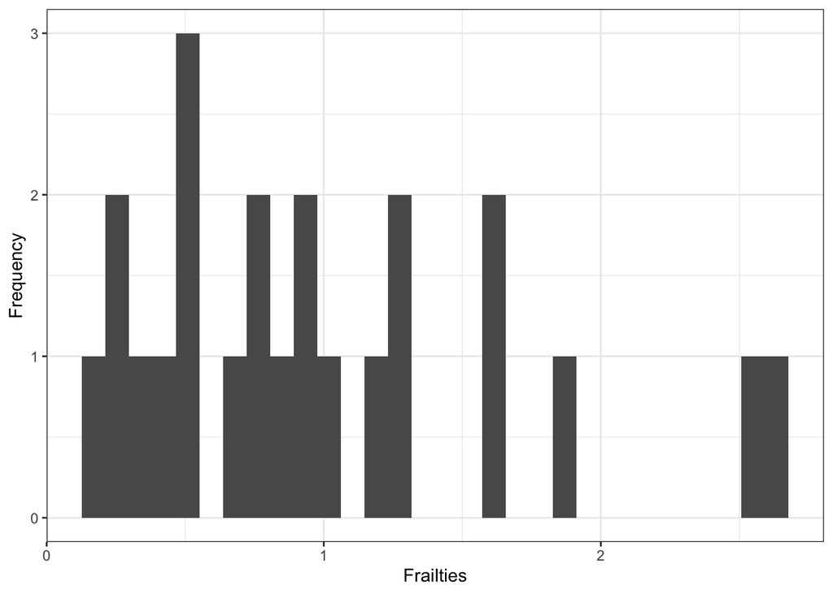

Figure 2: Histogram of the Estimated Frailties.

## Model Diagnostics

We can test whether the conditional proportional hazards model holds for the reduced Gamma shared frailty model.

```
         chisq df     p
length   0.161  1 0.689
handtime 4.037  1 0.045
GLOBAL   4.732  2 0.094
```

At a $\alpha = 0.05$ significance level, there is not enough evidence to suggest that the conditional proportional hazards assumption is violated for the overall model.

## Interpretation of Model Coefficients

The exponentiated coefficient for ‘length’ tells us that a one-centimeter increase in the length of a halibut is associated with a decrease in the relative risk of death by about 2.19%, assuming all other variables in the model are held constant. The exponentiated coefficient for ‘handtime’ tells us that a one-minute increase in the handling time of a halibut is associated with an increase in the relative risk of death by about 5.36%, assuming all other variables are held constant.

## Removing Outliers

We can see in the figure below that the survival times are pretty heavily skewed to the right.

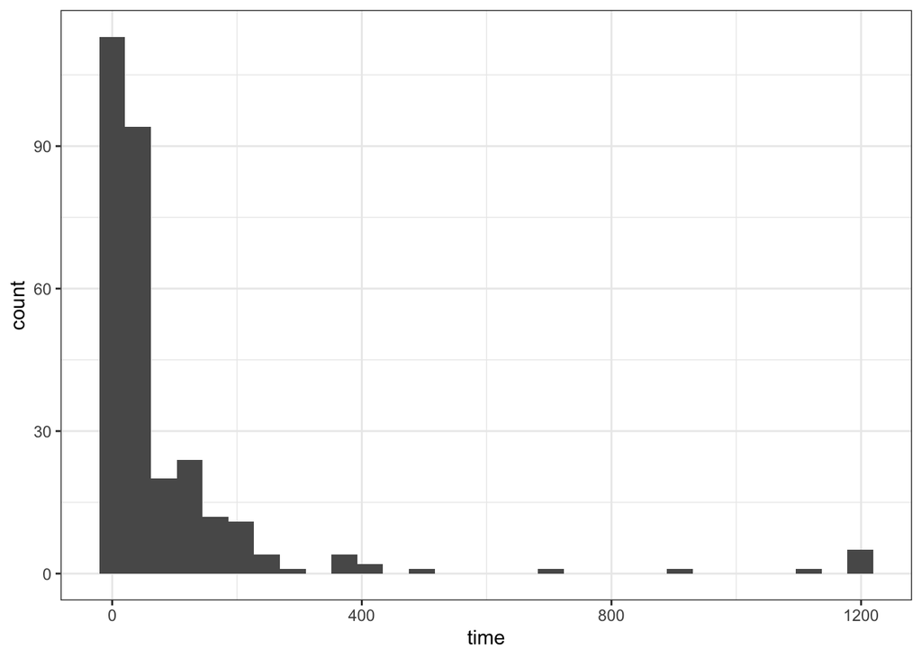

Figure 3: Histogram of Survival Times.

The table below shows us which observations have survival times greater than the 97.5th percentile.

|  | time | censor | towd | deldepth | length | handtime | logcat | cluster |
| --- | --- | --- | --- | --- | --- | --- | --- | --- |
| 26 | 1200 | 0 | 30 | 2 | 48 | 5 | 2.908 | D |
| 54 | 1200 | 0 | 30 | 2 | 45 | 11 | 6.311 | J |
| 90 | 1200 | 0 | 30 | 6 | 46 | 15 | 8.029 | M |
| 98 | 713 | 1 | 30 | 15 | 42 | 4 | 5.685 | N |
| 99 | 1200 | 0 | 30 | 15 | 47 | 5 | 5.685 | N |
| 106 | 905 | 1 | 30 | 15 | 35 | 7 | 5.685 | N |
| 139 | 1196 | 1 | 100 | 10 | 44 | 14 | 5.323 | P |
| 140 | 1097 | 1 | 100 | 6 | 48 | 6 | 4.059 | Q |

We removed these observations from the data and repeated the above procedure for answering Questions 1 and 2. The Kaplan-Meier estimates of survival for different tow durations can be seen below, along with the results of the log-rank test, and summary results from the shared Gamma frailty model fit. We can see that the estimated frailty variance decreased slightly while the interpretation for ‘length’ and ‘handtime’ did not change much. The conditional proportional hazards assumption does not appear to be violated by the overall model or by individual predictors.

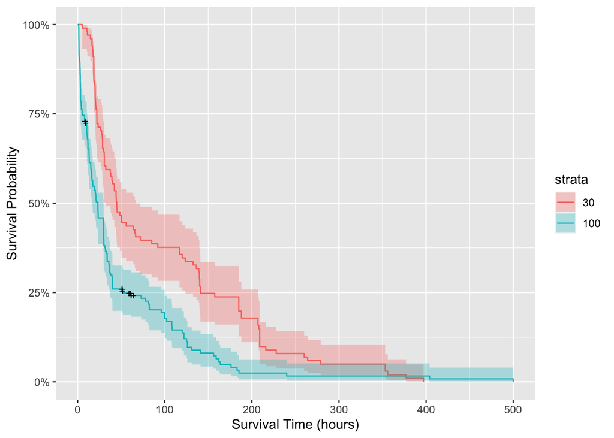

Figure 4: Kaplan-Meier Estimates of Survival Curves for Different Tow Durations.

```
Call:
survdiff(formula = Surv(time, censor) ~ towd, data = halibut_out)

           N Observed Expected (O-E)^2/E (O-E)^2/V
towd=30  101      101      139      10.5        24
towd=100 185      168      130      11.3        24

 Chisq= 24  on 1 degrees of freedom, p= 9e-07
```

```
Call:
emfrail(formula = Surv(time, censor) ~ length + handtime + cluster,
    data = halibut_out, control = zph_t.2)

Regression coefficients:
            coef exp(coef) se(coef) adj. se       z    p
length   -0.0203    0.9799   0.0114  0.0114 -1.7833 0.07
handtime  0.0513    1.0526   0.0116  0.0116  4.4251 0.00
Estimated distribution: gamma / left truncation: FALSE

Fit summary:
Commenges-Andersen test for heterogeneity: p-val  3.57e-07
no-frailty Log-likelihood: -1236.295
Log-likelihood: -1198.368
LRT: 1/2 * pchisq(75.9), p-val 1.53e-18

Frailty summary:
                   estimate lower 95% upper 95%
Var[Z]                0.492     0.249     0.984
Kendall's tau         0.197     0.111     0.330
Median concordance    0.194     0.108     0.330
E[logZ]              -0.266    -0.567    -0.129
Var[logZ]             0.632     0.282     1.606
theta                 2.033     1.016     4.020
Confidence intervals based on the likelihood function
```

```
          chisq df     p
length   0.0157  1 0.900
handtime 3.0206  1 0.082
GLOBAL   3.2517  2 0.197
```